[figure not shown]

# **Proyecto 1 - MDS7202 Laboratorio de Programación Científica para Ciencia de Datos 📚**

**MDS7202: Laboratorio de Programación Científica para Ciencia de Datos**

### Cuerpo Docente:

- Profesor: Ignacio Meza, Gabriel Iturra
- Auxiliar: Sebastián Tinoco
- Ayudante: Arturo Lazcano, Angelo Muñoz

*Por favor, lean detalladamente las instrucciones de la tarea antes de empezar a escribir.*

### Equipo:

- Simon Repolt
- Magdalena de la Fuente

### Link de repositorio de GitHub: `https://github.com/HexaPulsar/LabMDS`

Fecha límite de entrega 📆: 27 de Octubre de 2023.

## Reglas

- **Grupos de 2 personas.**
- Cualquier duda fuera del horario de clases al foro. Mensajes al equipo docente serán respondidos por este medio.
- Estrictamente prohibida la copia.
- Pueden usar cualquier material del curso que estimen conveniente.

[figure not shown]

En un Chile azotado por un profundo caos político-económico y el resurgimiento de programas de televisión de dudosa calidad, todas las miradas y esperanzas son depositadas en el éxito de un único evento: Santiago 2023. La nación necesitaba desesperadamente un respiro, y los Juegos de Santiago 2023 prometían ser una luz al final del túnel.

El Presidente de la República -conocido en las calles como Bombín-, consciente de la importancia de este evento para la revitalización del país, decide convocar a usted y su equipo en calidad de expertos en análisis de datos y estadísticas. Con gran solemnidad, el presidente les encomienda una importante y peligrosa: liderar un proyecto que permitiera caracterizar de forma automática y eficiente los datos generados por estos magnos juegos. Para esto, el presidente le destaca que la solución debe considerar los siguientes puntos:

- Caracterización automática de los datos
- La solución debe ser compatible con cualquier dataset
- Se les facilita el dataset *olimpiadas.parquet*, el cual recopila data de diferentes juegos olímpicos realizados en los últimos años

## 1.1 Creación de `Profiler` Class (4.0 puntos)

Cree la clase `Profiler`. Como mínimo, esta debe tener las siguientes funcionalidades:

1. El método constructor, el cual debe recibir los datos a procesar en formato `Pandas DataFrame`. Además, este método debe generar una carpeta en su directorio de trabajo con el nombre `EDA_fecha`, donde `fecha` corresponda a la fecha de ejecución en formato `DD-MM-YYYY`.
2. El método `summarize`, el cual debe caracterizar las variables del Dataset. Como mínimo, se espera que su método pueda:
   - Implementar una funcionalidad para filtrar y aplicar este método a una o más variables de interés.
   - Reportar el tipo de variable
   - Reportar el número y/o porcentaje de valores únicos de la variable
   - Reportar el número y/o porcentaje de valores nulos
   - Si la variables es numérica:
     - Reportar el número y/o porcentaje de valores cero, negativos y outliers
     - Reportar estadística descriptiva como el valor mínimo, máximo, promedio y los percentiles 25, 50, 75 y 100
   - Levantar una alerta en caso de encontrar alguna anomalía fuera de lo común (el criterio debe ser ajustable por el usuario)
   - Guardar sus resultados en el directorio `EDA_fecha/summary.txt`. El archivo debe separar de forma clara y ordenada los resultados de cada punto.
3. El método `plot_vars`, el cual debe graficar la distribución e interraciones de las variables del Dataset. Como mínimo, se espera que su método pueda:
   - Crear la carpeta `EDA_fecha/plots`
   - Implementar una funcionalidad para filtrar y aplicar este método a una o más variables de interés.
   - Para las variables numéricas:
     - Genere un gráfico de distribución de densidad
     - Grafique la correlación entre las variables
   - Para las variables categóricas:
     - Genere un histograma de las top N categorías (N debe ser un parámetro ajustable)
     - Grafique el coeficiente V de Cramer entre las variables
   - Guardar cada gráfico generado en la carpeta `EDA_fecha/plots` en formato `.pdf` y bajo el naming `variable.pdf`, donde `variable` es el nombre de la variable de interés
4. El método `clean_data`, el cual debe limpiar los datos para que luego puedan ser procesados. Como mínimo, se espera que su método pueda:
   - Crear la carpeta `EDA_fecha/clean_data`
   - Implementar una funcionalidad para filtrar y aplicar este método a una o más variables de interés.
   - Drop de valores duplicados
   - Implementar como mínimo 2 técnicas para tratar los valores nulos, como:
     - Drop de valores nulos
     - Imputar valores nulos con alguna técnica de imputación
     - Funcionalidad para escoger entre una técnica y la otra.
   - Una de las columnas del dataframe presenta datos *no atómicos*. Separe dicha columna en las columnas que la compongan.
     - Hint: ¿Qué caracteres permiten separar una columna de otra?
     - Para las pruebas con el dataset nuevo, puede esperar que exista al menos una columna con este tipo de problema. Asuma que los separadores serán los mismos, aunque el número de columnas a separar puede ser distinto.
   - Deberían usar `FunctionTransformer`.
   - Guardar los datos procesados en formato `.csv` en el path `EDA_fecha/clean_data/data.csv`
5. El método `scale`, el cual debe preparar adecuadamente los datos para luego ser consumidos por algún tipo de algoritmo. Como mínimo, se espera que su método pueda:
   - Crear la carpeta `EDA_fecha/scale`
   - Procesar de forma adecuada los datos numéricos y categóricos:
     - Su método debe recibir las técnicas de escalamiento como argumento de entrada (utilizar solo técnicas compatibles con el framework de `sklearn`)
     - Para los atributos numéricos, se transforme los datos con un escalador logarítmico y un `MinMaxScaler`
     - Asuma que no existen datos ordinales en su dataset
   - Guardar todo este procesamiento en un `ColumnTransformer`.
   - Guardar los datos limpios y transformados en formato `.csv` en el path `EDA_fecha/process/scaled_features.csv`
6. El método `make_clusters`, el cual debe generar clusters de los datos usando algún algoritmo de clusterización. Como mínimo, se espera que su método pueda:
   - Crear la carpeta `EDA_fecha/clusters`
   - Generar un estudio del codo donde señale la cantidad de clusters optimos para el desarrollo.
   - Su método debe recibir el algoritmo de clustering como argumento de entrada (utilizar solo algoritmos compatibles con el framework de `sklearn`).
   - No olvide pre procesar adecuadamente los datos antes de implementar la técnica de clustering.
   - En este punto es espera que generen un `Pipeline` de sklearn. Además, su método debería usar lo construido en los puntos 4 y 5.
   - Su método debe ser capaz de funcionar a partir de datos crudos (se descontará puntaje de lo contrario).
   - Una vez generado los clusters, proyecte los datos a 2 dimensiones usando su técnica de reducción de dimensionalidad favorita y grafique los resultados coloreando por cluster.
   - Guardar los datos con su respectivo cluster en formato `.csv` en el path `EDA_fecha/clusters/data_clusters.csv`. Guarde también los gráficos generados en el mismo path.
7. El método `detect_anomalies`, el cual debe detectar anomalías en los datos. Como mínimo, se espera que su método pueda:
   - Crear la carpeta `EDA_fecha/anomalies`
   - Implementar alguna técnica de detección de anomalías.
   - Al igual que el punto anterior, su método debe considerar los siguientes puntos:
     - No olvide pre procesar de forma adecuada los datos antes de implementar la técnica de detección de anomalía.
     - En este punto es espera que generen un `Pipeline` de sklearn. Además, su método debería usar lo construido en los puntos 4 y 5.
     - Su método debe ser capaz de funcionar a partir de datos crudos (se descontará puntaje de lo contrario).
     - Su método debe recibir el algoritmo como argumento de entrada
     - Una vez generado las etiquetas, proyecte los datos a 2 dimensiones y grafique los resultados coloreando por las etiquetas predichas por el detector de anomalías
   - Guardar los datos con su respectiva etiqueta en formato `.csv` en el path `EDA_fecha/anomalies/data_anomalies.csv`. Guarde también los gráficos generados en el mismo path.
8. El método `profile`, el cual debe ejecutar todos los métodos anteriores.
9. Crear el método `clearGarbage` para eliminar las carpetas/archivos creados/as por la clase `Profiler`.

Algunas consideraciones generales:

- Su clase será testeada con datos tabulares diferentes a los provistos. No desarrollen código *hardcodeado*: su clase debe ser capaz de funcionar para **cualquier** dataset.
- Aplique todo su conocimiento sobre buenas prácticas de programación: se evaluará que su código sea limpio y ordenado.
- Recuerden documentar cada una de las funcionalidades que implementen.
- Recuerden adjuntar sus `requirements.txt` junto a su entrega de proyecto. **El código que no se pueda ejecutar por imcompatibilidades de librerías no será corregido.**

```python
import numpy as np
import pandas as pd
import matplotlib.pyplot as plt
import os
import seaborn as sns
import datetime
import shutil
from scipy.stats import chi2_contingency
from sklearn.cluster import KMeans, DBSCAN, AgglomerativeClustering
from sklearn.pipeline import Pipeline
from sklearn.preprocessing import MinMaxScaler,FunctionTransformer,OneHotEncoder, LabelEncoder
from sklearn.compose import ColumnTransformer
from sklearn.decomposition import PCA
from tqdm import tqdm
from sklearn.base import is_classifier,is_outlier_detector
import re
from sklearn.ensemble import IsolationForest
import warnings as w
```

```python
#TODO En algunas funciones falta agregar prints diciendo que ha ocurrido durante la funcion
#
#
#TODO asegurarse de que los requirements esten correctos antes de entregar y que el pip freeze este al dia
#TODO documentar los metodos
```

```python
#pip freeze > requirements.txt
```

```python
class Profiler():

    def __init__(self,df:pd.DataFrame) -> None:
        self.df = df
        self.current_date = datetime.datetime.now().strftime(f"%d-%m-%Y")

        self.EDA_directory_name = f"EDA_{self.current_date}"
        self.PLOT_directory_name = f"{self.EDA_directory_name}/plots"
        self.CLEAN_directory_name = f"{self.EDA_directory_name}/clean_data"
        self.CLUSTERS_directory_name = f"{self.EDA_directory_name}/clusters"
        self.SCALE_directory_name = f"{self.EDA_directory_name}/scaled"
        self.ANOMALY_directory_name = f"{self.EDA_directory_name}/anomalies"

        self.categorical = self.df.select_dtypes(include=['object'])
        self.numerical = self.df.select_dtypes(include=['number'])

        try:
            if os.path.exists(self.EDA_directory_name):
                shutil.rmtree(self.EDA_directory_name)
            os.mkdir(self.EDA_directory_name)
            print(f"Directory '{self.EDA_directory_name}' created (overwritten) successfully.")
        except Exception as e:
            print(f"An error occurred: {e}")

    """Summarize: gives a summary of given or all variables in the dataset
        print_summarize: bool, if True, prints summary on screen, if not, it doesn't
        column_name: str or list: column name can be a string only if it is desired to summarize one variable, in that case
        column_name must be the name of said column. Must be a list containing the names of two or more variables if you want to
        summarize more than 1 variable

        returns: None

     """

    def summarize(self,print_summarize = True,column_name:str or list=None,everything=True):
        if everything and column_name !=None:
            raise Exception("No puedes tener everything en True si especificas columnas!")

        """detect_outliers is an auxiliary function that detects outliers in the dataset using the
        IQR method"""
        def detect_outliers(column):
            Q1 = column.quantile(0.25)
            Q3 = column.quantile(0.75)
            IQR = Q3 - Q1
            lower_bound = Q1 - 1.5 * IQR
            upper_bound = Q3 + 1.5 * IQR
            outliers = (column < lower_bound) | (column > upper_bound)
            return outliers.sum()

        file_path = f"{self.EDA_directory_name}/summary.txt"

        if everything:
            vars = self.df
        else:
            vars=self.df[column_name]
        numerical = vars.select_dtypes(include=['number'])
        with open(file_path, "w", encoding="utf-8") as f:
            tipos = '\n'.join(map(lambda x, y: f"{x}: {y}", vars.columns.to_list(), vars.dtypes))
            f.write("\n"+60*"-"+"\n")
            f.write("Los tipos de las variables son: "+"\n")
            f.write(tipos)
            f.write("\n"+60*"-"+"\n")
            nan_values = '\n'.join(map(lambda x, y: f"{x}: {y}", vars.columns.to_list(), vars.isna().sum().to_list()))
            f.write("Cantidad de NaNs por variable: "+"\n")
            f.write(nan_values)
            if vars.isna().sum().mean() > vars.shape[0]*0.1:
                w.warn("La cantidad de NaNs en promedio supera el 10% del dataset!")
            f.write("\n"+60*"-"+"\n")
            unique_values = '\n'.join(map(lambda x, y: f"{x}: {y}", vars.columns.to_list(), vars.nunique().to_list()))
            f.write("Cantidad de valores únicos por variable: "+"\n")
            f.write(unique_values)
            f.write("\n"+60*"-"+"\n")
            duplicated_values = self.df[self.df.duplicated()]
            f.write(f"Cantidad de valores duplicados: {str(len(duplicated_values))}")
            if self.numerical.shape[0] > 1: #si no hay numericas no hacer nada de esto
                f.write("\n"+60*"-"+"\n")
                nceros = '\n'.join(map(lambda x, y: f"{x}: {y}", numerical.columns.to_list(), (numerical == 0).sum().to_list()))
                f.write("Cantidad de ceros en las variables numericas: "+"\n")
                f.write(nceros)
                if (numerical == 0).sum().mean() > vars.shape[0]*0.1:
                    w.warn("La cantidad de ceros en promedio supera el 10% del dataset!")
                f.write("\n"+60*"-"+"\n")
                promedios =  '\n'.join(map(lambda x, y: f"{x}: {y}", numerical.columns.to_list(), numerical.mean().to_list()))
                f.write("Promedios de las variables numericas: "+"\n")
                f.write(promedios)
                f.write("\n"+60*"-"+"\n")
                negativos = '\n'.join(map(lambda x, y: f"{x}: {y}", numerical.columns.to_list(), (numerical < 0).sum().to_list()))
                f.write("Cantidad de negativos de las variables numericas: "+"\n")
                f.write(negativos)
                f.write("\n"+60*"-"+"\n")
                maximos = '\n'.join(map(lambda x, y: f"{x}: {y}", numerical.columns.to_list(), numerical.max().to_list()))
                f.write("Maximos de las variables numericas: "+"\n")
                f.write(maximos)
                f.write("\n"+60*"-"+"\n")
                minimos = '\n'.join(map(lambda x, y: f"{x}: {y}", numerical.columns.to_list(), numerical.min().to_list()))
                f.write("Mínimos de las variables numericas: "+"\n")
                f.write(minimos)
                f.write("\n"+60*"-"+"\n")
                outliers = '\n'.join(map(lambda x, y: f"{x}: {y}", numerical.columns.to_list(), numerical.apply(detect_outliers)))
                f.write("Outliers de las variables numericas: "+"\n")
                f.write(outliers)
                f.write("\n"+60*"-"+"\n")
                values_perc = [0.25, 0.5, 0.75, 1.0]
                percentiles = self.numerical.quantile(values_perc).values
                for idx,perc in enumerate(values_perc):
                    f.write("Percentil " + str(perc*100) + " de las variables numericas: "+"\n")
                    perc_val = '\n'.join(map(lambda x, y: f"{x}: {y}", numerical.columns.to_list(), percentiles[idx]))
                    f.write(perc_val)
                    f.write("\n"+60*"-"+"\n")
            f.close()
            print(f"Summary.txt has been successfully exported too {self.EDA_directory_name}")
            if print_summarize:
                with open(file_path, 'r') as file:
                    file_content = file.read()
                    print(file_content)
```

```python
    def plot_vars(self,column_name= None,N_adj = 10):
        """
        Plots various visualizations for the specified column(s) in the DataFrame.

        Args:
            column_name (str or list): The name of the column or a list of column names to visualize.
            N_adj (int, optional): The number of top categories to consider in histograms. Defaults to 10.

        Raises:
            ValueError: If the input columns list is empty.

        Returns:
            None
        """
        try:
            if os.path.exists(self.PLOT_directory_name):
                shutil.rmtree(self.PLOT_directory_name)
            os.mkdir(self.PLOT_directory_name)
            print(f"Directory '{self.PLOT_directory_name}' created (overwritten) successfully.")
        except Exception as e:
            print(f"An error occurred: {e}")

        def correlation_plot(variables:list):

            """
            Plots a correlation matrix heatmap for a list of numerical variables.

            Args:
                variables (list): A list of column names representing numerical variables.

            Returns:
                None
            """

            #TODO revisar que los elementos de la lista sean todos str try/except
            correlation_matrix = np.corrcoef(self.numerical[variables], rowvar=False)
            plt.figure()
            sns.heatmap(correlation_matrix, cmap='coolwarm', annot=True, fmt='.2f', xticklabels=variables, yticklabels=variables)
            plt.title('Correlation Matrix')


        def histogram(var: pd.Series, N: int):
            """
            Plots a histogram for a categorical variable.

            Args:
                var (pd.Series): A pandas Series representing a categorical variable.
                N (int): The number of top categories to display in the histogram.

            Returns:
                None
            """
            category_counts = var.value_counts()
            top_N_categories = category_counts.head(N)
            plt.bar(top_N_categories.index, top_N_categories.values)
            plt.xlabel('Category')
            plt.ylabel('Frequency')
            plt.xticks(rotation=90)
            plt.title(f'Top {N} Categories Histogram for variable {var.name}')

        def cramers_v(confusion_matrix):
            """
            Calculates Cramer's V statistic for two categorical variables.

            Args:
                confusion_matrix (pd.DataFrame): The contingency table of two categorical variables.

            Returns:
                float: The Cramer's V statistic.

            Notes:
                Cramer's V is a measure of association for categorical variables.

            """
            chi2 = chi2_contingency(confusion_matrix)[0]
            n = confusion_matrix.sum().sum()
            phi2 = chi2 / n
            r, k = confusion_matrix.shape
            phi2corr = max(0, phi2 - ((k - 1) * (r - 1)) / (n - 1))
            rcorr = r - ((r - 1)**2) / (n - 1)
            kcorr = k - ((k - 1)**2) / (n - 1)
            return np.sqrt(phi2corr / min((kcorr - 1), (rcorr - 1)))

        def cramer_v_plot(variables):
            """
            Plots a heatmap of Cramer's V values for all pairs of categorical variables.

            Args:
                variables (list): A list of column names representing categorical variables.

            Returns:
                None
            """
            categorical_cols = self.categorical[variables]
            results = pd.DataFrame(index=categorical_cols.columns, columns=categorical_cols.columns, dtype=float)
            for col1 in categorical_cols.columns:
                for col2 in categorical_cols.columns:
                    confusion_matrix = pd.crosstab(categorical_cols[col1], categorical_cols[col2])
                    results.loc[col1, col2] = cramers_v(confusion_matrix)
            plt.figure()
            sns.heatmap(results, annot=True, cmap="coolwarm", linewidths=.5)
            plt.title("Cramer's V Heatmap")

        try:
            if column_name is None:
                present_num = self.numerical
                present_cat = self.categorical

                if len(present_num) > 1:
                    correlation_plot(present_num.columns)
                    plt.gcf()
                    plt.savefig(f"{self.PLOT_directory_name}/corr.pdf", format = 'pdf')
                    plt.show()

                if len(present_cat) > 1:
                    cramer_v_plot(present_cat.columns)
                    plt.gcf()
                    plt.savefig(f"{self.PLOT_directory_name}/cramer_v.pdf", format = 'pdf')
                    plt.show()

                for col in self.df.columns:
                    if col in self.numerical.columns:
                        var = self.df[col]
                        var.plot.density(title = f"Plot de densidad para la variable {col}")
                        plt.savefig(f"{self.PLOT_directory_name}/{col}.pdf", format = 'pdf')
                        plt.show()
                    if col in self.categorical.columns:
                        histogram(self.df[col],N= N_adj)
                        plt.gcf()
                        plt.savefig(f"{self.PLOT_directory_name}/{col}.pdf", format = 'pdf')
                        plt.show()

            if isinstance(column_name, str):
                if column_name in self.numerical:
                    var = self.df[column_name]
                    var.plot.density(title=f"Plot de densidad para la variable {column_name}")
                    plt.savefig(f"{self.PLOT_directory_name}/{column_name}.pdf", format = 'pdf')
                    plt.show()
                else:
                    var = self.df[column_name]
                    histogram(var,N= N_adj)
                    plt.gcf()
                    plt.savefig(f"{self.PLOT_directory_name}/{column_name}.pdf", format = 'pdf')
                    plt.show()


            elif isinstance(column_name,list):
                present_num = [i for i in self.numerical if i in column_name]
                present_cat = [i for i in self.categorical if i in column_name]
```

```python
                if present_num and len(present_num) > 1:
                    correlation_plot(present_num)
                    plt.gcf()
                    plt.savefig(f"{self.PLOT_directory_name}/corr.pdf", format = 'pdf')
                    plt.show()

                if present_cat and len(present_cat) > 1:
                    cramer_v_plot(present_cat)
                    plt.gcf()
                    plt.savefig(f"{self.PLOT_directory_name}/cramer_v.pdf", format = 'pdf')
                    plt.show()

                for col in column_name:
                    if col in self.numerical.columns:
                        var = self.df[col]
                        var.plot.density(title = f"Plot de densidad para la variable {col}")
                        plt.savefig(f"{self.PLOT_directory_name}/{col}.pdf", format = 'pdf')
                        plt.show()
                    if col in self.categorical.columns:
                        histogram(self.df[col],N= N_adj)
                        plt.gcf()
                        plt.savefig(f"{self.PLOT_directory_name}/{col}.pdf", format = 'pdf')
                    plt.show()

        except Exception as e:
            print(f'Exception Error: {e}')


    """Clean data: Cleans the data of given column(s)
        non_atomic: list , if the dataset contains non-atomic columns, then
        this parameter receives a list of the names of said non atomic columns

        column_name: list or str: name of the column to clean. Must be a list of names of variables
        if it is desired to clean more than 1 column
        everything: bool. If true, cleans the whole dataset, if not, cleans given columns

        If everything is true then column_name must be None.

        nan_treatment: str: Must be "delete" in order to remove all NaNs, "zeros" if desired to replace all NaNs by
        zeros, "mean" if desired to replace all NaNs by the mean of its column


        returns: None

    """
    def clean_data(self, column_name=None, everything=True, nan_treatment="delete"):

        non_atomic = eval(input("Especificar columna no atomica. Escribir None si no hay \n"))

        if everything and column_name !=None:
            raise Exception("No puedes tener everything en True si especificas columnas!")
        try:
            if os.path.exists(self.CLEAN_directory_name):
                shutil.rmtree(self.CLEAN_directory_name)
            os.mkdir(self.CLEAN_directory_name)
            print(f"Directory '{self.CLEAN_directory_name}' created (overwritten) successfully.")
        except Exception as e:
            print(f"An error occurred: {e}")


        file_path = f"{self.CLEAN_directory_name}/data.csv"

        if everything:
            to_clean = self.df
        else:
            to_clean = self.df[column_name]

        def atomize_column(X, column_name_not_atomic):
            split_names = column_name_not_atomic.split('-')
            n_splits = len(split_names)
            new_df = pd.DataFrame(columns=split_names)

            def process_split(x):
                split = re.findall(r'\d+\.\d+', x)
                if len(split) < n_splits:
                    split += [np.nan] * (n_splits - len(split))
                return {split_names[i]: split[i] for i in range(n_splits)}

            non_atomic_data = X[column_name_not_atomic].apply(process_split)
            new_df = pd.DataFrame(list(non_atomic_data))
            return new_df

        def clean_data_func(X, non_atomic=None, column_name=None, nan_treatment="delete"):
            df = X.copy()

            if non_atomic != None:
                for i in non_atomic:
                    to_add = atomize_column(df, i)
                    df = pd.concat([df, to_add], axis=1)
                    df = df.drop(i, axis=1)
            df = df.drop_duplicates()

            if nan_treatment == "delete":
                df = df.dropna()
            elif nan_treatment == "mean":
                df = df.apply(pd.to_numeric, errors='coerce')
                df = df.fillna(df.mean())
            elif nan_treatment == "zeros":
                df = df.fillna(0)
            else:
                raise ValueError("Invalid nan_treatment option!")
            return df

        clean_data_transformer = FunctionTransformer(clean_data_func,kw_args={'non_atomic': non_atomic,\
                    'column_name': column_name,'nan_treatment': nan_treatment})

        # Apply the FunctionTransformer to your DataFrame
        df_limpio = clean_data_transformer.transform(to_clean)

        # Save the cleaned DataFrame to a CSV file
        df_limpio.to_csv(f"{self.CLEAN_directory_name}/data.csv", index=False)
        print("Percentage of data retained:",np.round((df_limpio.shape[0] / to_clean.shape[0])*100,2), '%')
        print("Data limpia ha sido guardada en: ",f"{self.CLEAN_directory_name}/data.csv")


    def scale(self, categorical_method=LabelEncoder()):
        try:
            if os.path.exists(self.SCALE_directory_name):
                shutil.rmtree(self.SCALE_directory_name)
            os.mkdir(self.SCALE_directory_name)
            print(f"Directory '{self.SCALE_directory_name}' created (overwritten) successfully.")
        except Exception as e:
            print(f"An error occurred: {e}")

        file_path = f"{self.SCALE_directory_name}/scaled_features.csv"
        clean_path = f"{self.CLEAN_directory_name}/data.csv"
        try:
            clean_data = pd.read_csv(clean_path)
            num_cols = clean_data.select_dtypes(include=['float64', 'int64']).columns
            cat_cols = clean_data.select_dtypes(include=['object']).columns
            numerical_transformer = Pipeline(steps=[('log_scaler', FunctionTransformer(np.log1p)),('minmax_scaler', MinMaxScaler())])

            if categorical_method is not None:
                if isinstance(categorical_method, LabelEncoder):
                    categorical_transformer = FunctionTransformer(
                        lambda x: x.apply(lambda col: categorical_method.fit_transform(col.astype(str)).astype(int)))
                else:
                    categorical_transformer = Pipeline(steps=[('categorical_encoder', categorical_method)])
                preprocessor = ColumnTransformer(transformers=[('num', numerical_transformer, num_cols),('cat', categorical_transformer, cat_cols)])
            else:
                preprocessor = ColumnTransformer(transformers=[('num', numerical_transformer, num_cols)])
```

```python
            pipe = Pipeline(steps=[('preprocessor', preprocessor)])
            transformed_data = pipe.fit_transform(clean_data)

            if categorical_method is not None:
                if isinstance(categorical_method, LabelEncoder):
                    cat_transformed_cols = cat_cols
                else:
                    cat_transformed_cols = preprocessor.named_transformers_['cat'].named_steps['categorical_encoder'].get_feature_names_out(cat_cols)
                if isinstance(categorical_method, OneHotEncoder) and categorical_method.sparse:
                    transformed_data = transformed_data.toarray()
                transformed_cols = num_cols.tolist() + cat_transformed_cols.tolist()
            else:
                transformed_cols = num_cols.tolist()

            transformed_df = pd.DataFrame(transformed_data, columns=transformed_cols)
            transformed_df.to_csv(file_path, index=False)
            print("Data escalada ha sido exportada a "+file_path)
        except Exception as e:
            print(f"An error occurred: {e}")



    def make_clusters(self, clustering_algorithm= KMeans(), n_clusters = None, columns_name=None):

        """Create clusters using K-Means and visualize the results.

        This function creates clusters from the input data using K-Means clustering.
        It can also automatically determine the optimal number of clusters using
        the elbow method. The resulting clusters are visualized in a scatter plot
        using PCA.

        Args:
            n_clusters (int, optional): The number of clusters to create. If None, the
                function will automatically determine the optimal number of clusters
                using the elbow method. Defaults to None.
            columns_name (list, optional): List of column names to use for clustering.
                If None, all columns from the DataFrame are used. Defaults to None.

        Returns:
            None

        Note:
            If `n_clusters` is not provided, this function will determine the optimal
            number of clusters using the elbow method. It is recommended to set
            `n_clusters` to None for optimal results.
        """
        def auto_elbow_method(data,n_clusters_range:np.linspace = range(1,15),_n_init = 10, plot_elbow = True):
            """auto elbow method for kmeans

            Args:
                data (_type_): data to clusterize
                n_clusters_range (np.linspace): range of n_clusters for elbow method
                _n_init (int, optional): number of kmeans init. Defaults to 5.
                _random_state (int, optional): for replicability. Defaults to 42.
                plot (bool, optional): plots elbow method. Defaults to False.

            Returns:
                _n_clusters_ (int): returns number of clusters for kmeans
            """
            # Range of cluster numbers to try
            # Initialize an empty list to store the variance explained by each cluster
            inertia = []

            # Perform K-Means clustering for different values of k
            for n_clusters in tqdm(n_clusters_range,desc='testing clusters in elbow method'):
                kmeans = KMeans(n_clusters=n_clusters,n_init=_n_init)
                kmeans.fit(data)
                inertia.append(kmeans.inertia_)

            if plot_elbow:
                # Create the Elbow Method graph
                plt.figure()
                plt.plot(n_clusters_range, inertia, marker='o')
                plt.title('Elbow Method for Optimal K')
                plt.xlabel('Number of Clusters (K)')
                plt.ylabel('Variance Explained (Inertia)')
                plt.grid(True)
                plt.show()
            variation = [(inertia[i] - inertia[i+1])/ inertia[i] * 100 for i in range(len(inertia)-1)]
            n_clusters = n_clusters_range[variation.index(max(variation)) + 1]
            print(f"Optimal n_clusters is {int(n_clusters)}")
            return n_clusters

        def reduce_and_plot(data):
            pca = PCA()
            cluster_pipeline = Pipeline([
            ('clustering', clustering_algorithm),
            ('pca', pca)
            ])
            cluster_labels = cluster_pipeline['clustering'].fit_predict(data)
            X_pca = cluster_pipeline['pca'].fit_transform(data)
            sns.scatterplot(x=X_pca[:, 0], y=X_pca[:, 1], hue=cluster_labels, palette='viridis',markers='.',s = 40,legend=False)
            plt.title('PCA Scatter Plot with Clusters')
            plt.xlabel('PCA Component 1')
            plt.ylabel('PCA Component 2')

            plt.show()
            return cluster_labels

        try:
            if os.path.exists(self.CLUSTERS_directory_name):
                shutil.rmtree(self.CLUSTERS_directory_name)
            os.mkdir(self.CLUSTERS_directory_name)
            print(f"Directory '{self.CLUSTERS_directory_name}' created (overwritten) successfully.")
            scaled_path = f"{self.SCALE_directory_name}/scaled_features.csv"

            if os.path.exists(scaled_path):
                print(f"The file '{scaled_path}' exists.")
            else:
                print(f"The file '{scaled_path}' does not exist. Calling a method...")
                self.clean_data()
                self.scale()
            data = pd.read_csv(f"{self.SCALE_directory_name}/scaled_features.csv")

            if columns_name is None:
                if isinstance(clustering_algorithm,KMeans) and n_clusters is None:
                    print(f'n_clusters is set to None. n_clusters will be initialized via the internal auto_elbow_method function.')
                    n_clusters =  auto_elbow_method(data,range(1,15))

                    print(f"The optimal number of clusters (k) is: {n_clusters}")
                    clustering_algorithm.set_params(n_clusters = n_clusters)
                cluster_labels = reduce_and_plot(data)


            elif isinstance(columns_name,list):
                data = data[columns_name]
                if isinstance(clustering_algorithm,KMeans) and n_clusters is None:
                    print(f'n_clusters is set to None. n_clusters will be initialized via the internal auto_elbow_method function.')
                    n_clusters =  auto_elbow_method(data,range(1,15))
```

```python
                    print(f"The optimal number of clusters (k) is: {n_clusters}")
                    clustering_algorithm.set_params(n_clusters = n_clusters)
                cluster_labels = reduce_and_plot(data)

            data_with_clusters = pd.DataFrame({'Cluster': cluster_labels})
            data_with_clusters = pd.concat([data,data_with_clusters],axis = 1)
            data_with_clusters.to_csv(f'{self.CLUSTERS_directory_name}/data_clusters.csv',index=False)
        except Exception as e:
            print(f"An error occurred: {e}")



    def detect_anomalies(self,algoritmo=IsolationForest(), algoritmo_params=None,tipo="limpio",columns_name = None,everything=True):

        try:
            if os.path.exists(self.ANOMALY_directory_name):
                shutil.rmtree(self.ANOMALY_directory_name)
            os.mkdir(self.ANOMALY_directory_name)
            print(f"Directory '{self.ANOMALY_directory_name}' created (overwritten) successfully.")
        except Exception as e:
            print(f"An error occurred: {e}")

        path_file=f'{self.ANOMALY_directory_name}/data_anomalies.csv'

        scaled_path = f"{self.SCALE_directory_name}/scaled_features.csv"
        if os.path.exists(scaled_path):
            print(f"The file '{scaled_path}' exists.")
        else:
            print(f"The file '{scaled_path}' does not exist. Calling a method...")
            self.clean_data()
            self.scale()

        data = pd.read_csv(scaled_path)
        if everything != True and isinstance(columns_name,list) == True:
            data = data[columns_name]
        if algoritmo_params is None:
            algoritmo_params = {}

        if not (is_classifier(algoritmo) or is_outlier_detector(algoritmo)):
            raise ValueError("Algoritmo debe ser parte del framework de sklearn")

        model = algoritmo.set_params(**algoritmo_params)
        pca = PCA(n_components=2)

        pipeline = Pipeline([('pca', pca),
                            ('anomaly_detection', model)])

        pipeline.fit(data)
        predictions = pipeline.predict(data)
        data['Anomalias'] = predictions

        print(pipeline.steps[0])
        X_pca = pipeline['pca'].fit_transform(data)
        ax=sns.scatterplot(x=X_pca[:, 0], y=X_pca[:, 1], hue=data['Anomalias'], palette='viridis',markers='.')
        plt.title('PCA Scatter Plot with Clusters')
        plt.xlabel('PCA Component 1')
        plt.ylabel('PCA Component 2')
        plt.show()
        plt.savefig(f'{self.ANOMALY_directory_name}/gráfico.pdf', format='pdf')
        data.to_csv(path_file)
        print("Anomalias guardadas en: ",path_file)

    def clearGarbage(self):
            """
            Deletes all contents within the 'EDA_fecha' folder but leaves the folder itself.

            Removes all files and subfolders within the 'EDA_fecha' directory while keeping the directory itself.

            Args:
                None

            Returns:
                None
            """
            for raiz, carpetas, archivos in os.walk(self.EDA_directory_name, topdown=False):
                for folder in carpetas:
                    folder_path = os.path.join(raiz, folder)
                    shutil.rmtree(folder_path)
                for file in archivos:
                    file_path = os.path.join(raiz, file)
                    os.remove(file_path)

    def profile(self):
        """
        Executes all callable methods of the class, excluding specific methods.

        Calls all callable methods of the class except those listed in 'no_incluir' list.

        Args:
            None

        Returns:
            None
        """
        metodos = [method for method in dir(self) if callable(getattr(self, method)) and not method.startswith("__")]
        metodos.sort(key=lambda x: getattr(self, x).__code__.co_firstlineno)
        no_incluir = ["profile", "clearGarbage"]
        for nombre in metodos:
            if nombre not in no_incluir:
                metodo = getattr(self, nombre)
                metodo()
```

```python
test = pd.read_parquet('olimpiadas.parquet')[:10000]
display(test)
```

|  | ID | Name | Sex | Team | NOC | Games | Year | Season | City | Sport | Event | Medal | age-height-weight |
| --- | --- | --- | --- | --- | --- | --- | --- | --- | --- | --- | --- | --- | --- |
| 0 | 1 | A Dijiang | M | China | CHN | 1992 Summer | 1992 | Summer | Barcelona | Basketball | Basketball Men's Basketball | None | 24.0*180.0?80.0 |
| 1 | 2 | A Lamusi | M | China | CHN | 2012 Summer | 2012 | Summer | London | Judo | Judo Men's Extra-Lightweight | None | 23.0(170.0?60.0 |
| 2 | 3 | Gunnar Nielsen Aaby | M | Denmark | DEN | 1920 Summer | 1920 | Summer | Antwerpen | Football | Football Men's Football | None | 24.0(nan?nan |
| 3 | 4 | Edgar Lindenau Aabye | M | Denmark/Sweden | DEN | 1900 Summer | 1900 | Summer | Paris | Tug-Of-War | Tug-Of-War Men's Tug-Of-War | Gold | 34.0:nan?nan |
| 4 | 5 | Christine Jacoba Aaftink | F | Netherlands | NED | 1988 Winter | 1988 | Winter | Calgary | Speed Skating | Speed Skating Women's 500 metres | None | 21.0(185.0?82.0 |
| ... | ... | ... | ... | ... | ... | ... | ... | ... | ... | ... | ... | ... | ... |
| 9995 | 5460 | Kiyoshi Asai | M | Japan | JPN | 1964 Summer | 1964 | Summer | Tokyo | Athletics | Athletics Men's 4 x 100 metres Relay | None | 24.0:167.0?60.0 |
| 9996 | 5461 | Tadashi Asai | M | Japan | JPN | 1956 Summer | 1956 | Summer | Melbourne | Wrestling | Wrestling Men's Flyweight, Freestyle | None | 20.0:162.0?57.0 |
| 9997 | 5461 | Tadashi Asai | M | Japan | JPN | 1960 Summer | 1960 | Summer | Roma | Wrestling | Wrestling Men's Bantamweight, Freestyle | None | 24.0*162.0?57.0 |
| 9998 | 5462 | Yoshiro Asakuma | M | Japan | JPN | 1936 Summer | 1936 | Summer | Berlin | Athletics | Athletics Men's High Jump | None | 22.0*180.0?65.0 |
| 9999 | 5463 | Tony J. Asamali | M | Philippines | PHI | 1968 Summer | 1968 | Summer | Mexico City | Swimming | Swimming Men's 200 metres Freestyle | None | 21.0(193.0?64.0 |

10000 rows × 13 columns

## 1.2 Caracterizar datos de Olimpiadas (2.0 puntos)

A partir de la clase que hemos desarrollado previamente, procederemos a realizar un análisis exhaustivo de los datos proporcionados en el enunciado. Este análisis se presentará en forma de un informe contenido en el mismo Jupyter Notebook y abordará los siguientes puntos:

1. Introducción
   - Se proporcionará una breve descripción del problema que estamos abordando y se explicará la metodología que se seguirá.

Elaborar una breve introducción con todo lo necesario para entender qué realizarán durante su proyecto. La idea es que describan de manera formal el proyecto con sus propias palabras y logren describir algunos aspectos básicos tanto del dataset como del análisis a realizar sobre los datos.

Por lo anterior, en esta sección ustedes deberán ser capaces de:

- Describir la tarea asociada al dataset.
- Describir brevemente los datos de entrada que les provee el problema.
- Plantear hipótesis de cómo podrían abordar el problema.
2. Análisis del EDA (Análisis Exploratorio de Datos)
   - Se discutirán las observaciones y conclusiones obtenidas acerca de los datos proporcionados. A lo largo de su respuesta, debe responder preguntas como:
     - ¿Como se comportan las variables numéricas? ¿y las categóricas?
     - ¿Existen valores nulos en el dataset? ¿En qué columnas? ¿Cuantos?
     - ¿Cuáles son las categorías y frecuencias de las variables categóricas?
     - ¿Existen datos duplicados en el conjunto?
     - ¿Existen relaciones o patrones visuales entre las variables?
     - ¿Existen anomalías notables o preocupantes en los datos?
3. Creación de Clusters y Anomalías
   - Se justificará la elección de los algoritmos a utilizar y sus hiperparámetros. En el caso de clustering, justifique además el número de clusters.
4. Análisis de Resultados
   - Se examinarán los resultados obtenidos a partir de los clústers y anomalías generadas. ¿Se logra una separación efectiva de los datos? Entregue una interpretación de lo que representa cada clúster y anomalía.
5. Conclusión
   - Se resumirán las principales conclusiones del análisis y se destacarán las implicaciones prácticas de los resultados obtenidos.

## 1. Introducción

Una de las principales tareas en el mundo del Data Science es lograr proveer insights sobre la data que se está estudiando. Comunmente, la data puede ser de gran volumen, con muchos datapoints y múltiples atributos. Para procesar esta data es necesario construir funcionalidades que procesen la data y para esto el uso de programación orientada a objetos es la mejor opción.

En esta ocasión se ha solicitado llevar a cabo un análisis sobre el dataset `'olimpiadas.parquet'`, de manera de obtener los mencionados insights. El dataset provisto cuenta con información acerca de los resultados de los juegos olímpicos a través del tiempo. Se mencionan los participantes, su nacionalidad, año de participación, temporada (juegos de invierno o verano), ciudad, disciplina, evento, si se ha ganado medalla y detalles acerca de la edad, el peso y la altura del participante.

Si bien se podría construir un perfilador (profiler) que estudiara automáticamente el dataset en específico, se ha solicitado que el perfilador sea agnóstico al dataset de entrada, siendo la caracterización automática, cosa que esta solución sea aplicable a cualquier dataset.

Para esto, es posible construir una clase de Python que lleve a cabo este procesamiento, siendo agnóstica a la data que se le ingresa y provea insights automatizados sobre la data. Esta es la hipótesis que se busca confirmar durante este proyecto. Gracias a la programación orientada a objetos, es posible crear un programa que reciba data como entrada, y a través de los atributos definidos en esta clase, y los métodos programados para estudiar la data, generar insights.

En este proyecto se construyó la clase `Profiler()`, la cual recibe un dataframe y crea un perfil del dataset a través de sus métodos.

La clase Profiler() contiene los sigueintes métodos:

1. `summarize()`: caracteriza las variables del dataset entregado al objeto profiler.
2. `plot_vars`: grafica las variables del dataset. Puede graficar todas las columnas del dataset o bien recibir una lista de nombres de las columnas del dataset. El método graficará correlación para las variables numéricas, cramer V para las variables categóricas, densidad para las variables numéricas y gráficos de frecuencia para las variables categóricas. El número de columnas admitidas en los gráficos de frecuencia es ajustable a través del parámetro `N_adj`.
3. `clean_data()`: limpia los datos. Es parte de las opciones de preprocesamiento de la clase.
4. `scale()`: escala la data, es parte de las opciones de preprocesamiento de la clase.
5. `make_clusters()`: lanza una instancia de Kmeans() de sklearn. El número de clusters puede ser entregado al algoritmo a través del parámetro `n_clusters`. De lo contrario, se asignará un número óptimo de clusters a través del método del codo.
6. `detect_anomalies()` detecta anomalías basado enun algoritmo de detección de anomalías provisto por el usuario.
7. `profile()`: ejecuta todos los métodos anteriores.
8. `clearGarbage()` elimina todos los archivos generados por profiler.

Además, cuenta con los sigueintes atributos:

1. `self.df`: almacena el dataset a perfilar.
2. `self.current_date`: almacena la fecha actual para construir el directorio donde se almacenarán los resultados del perfilador.
3. `self.EDA_directory_name`: directorio donde se almacenan los resultados del método EDA.
4. `self.PLOT__directory`: directorio donde se almacenan los gráficos generados.
5. `self.CLEAN_directory_name`: directorio donde se almacenan los datos limpiados.
6. `self.CLUSTERS_directory_name`: directorio donde se almacenan los resultados de la generación de clusters.
7. `self.SCALE_directory_name`: directorio donde se almacenan los resultados del escalamiento.
8. `self.categorical`: almacena un dataframe que contiene solo las variables categóricas del dataframe original.
9. `self.numerical`: almacena un dataframe que contiene solo las variables numéricas del dataframe original.

## 2.Análisis EDA

Como mencionado anteriormente, el dataset entregado en esta ocasión cuenta con diversa información acerca de distintos deportistas en la historia de los juegos olímpicos. La clase `Profiler()` programada permitirá estudiar estos datos de manera rápida, ya que generará información útil respecto al dataset con simplemente llamar a los métodos que tiene.

```python
test = pd.read_parquet('olimpiadas.parquet')
test = test.sample(n = 10000)
display(test.head())
```

|  | ID | Name | Sex | Team | NOC | Games | Year | Season | City | Sport | Event | Medal | age-height-weight |
| --- | --- | --- | --- | --- | --- | --- | --- | --- | --- | --- | --- | --- | --- |
| 113284 | 57381 | Chintamoni Kar | M | Great Britain | GBR | 1948 Summer | 1948 | Summer | London | Art Competitions | Art Competitions Mixed Sculpturing, Statues | Silver | 33.0:nan?nan |
| 109404 | 55313 | Per Christian Johnsen | M | Norway | NOR | 1952 Summer | 1952 | Summer | Helsinki | Canoeing | Canoeing Men's Kayak Singles, 1,000 metres | None | 25.0?nan?nan |
| 86269 | 43730 | Jean Francois Guillou | M | France | FRA | 1952 Summer | 1952 | Summer | Helsinki | Gymnastics | Gymnastics Men's Horizontal Bar | None | 21.0*nan?nan |
| 264047 | 132125 | Robina Muqim Yaar | F | Afghanistan | AFG | 2008 Summer | 2008 | Summer | Beijing | Athletics | Athletics Women's 100 metres | None | 22.0(180.0?56.0 |
| 102980 | 52102 | Miguel ngel Indurin Larraya | M | Spain | ESP | 1984 Summer | 1984 | Summer | Los Angeles | Cycling | Cycling Men's Road Race, Individual | None | 20.0(188.0?79.0 |

Es posible ver las columnas Name, Sex, Team, NOC, Games, etc. Corresponden a distintos atributos asociados al atleta, al cual se le refiere por nombre en la columna "Name".

Para inicializar el perfilador se llama a la clase `Profiler()` y se le entrega el dataset de interés.

```python
test_class = Profiler(test)
```

```
Directory 'EDA_10-11-2023' created (overwritten) successfully.
```

Un mensaje printeado en la consola indica que se ha creado un directorio. En este se almacenará la data generada por el perfilador. Si el directorio ya existía, será sobreescrito para evitar confusiones.

La clase `Profiler()` contiene como atributo al dataframe entregado a la inicialización. Esto significa que al llamar *self.df* se pueda acceder al dataframe entregado. Aquí se pueden aprovechar las funciones sobre dataframes que provee pandas, como por ejemplo el método `.describe()`.

```python
test_class.df.describe().round(2)
```

|  | ID | Year |
| --- | --- | --- |
| count | 10000.00 | 10000.00 |
| mean | 67896.09 | 1978.09 |
| std | 38946.80 | 29.98 |
| min | 5.00 | 1896.00 |
| 25% | 34819.50 | 1960.00 |
| 50% | 67950.00 | 1988.00 |
| 75% | 101312.25 | 2002.00 |
| max | 135566.00 | 2016.00 |

```python
test_class.df.head()
```

|  | ID | Name | Sex | Team | NOC | Games | Year | Season | City | Sport | Event | Medal | age-height-weight |
| --- | --- | --- | --- | --- | --- | --- | --- | --- | --- | --- | --- | --- | --- |
| 113284 | 57381 | Chintamoni Kar | M | Great Britain | GBR | 1948 Summer | 1948 | Summer | London | Art Competitions | Art Competitions Mixed Sculpturing, Statues | Silver | 33.0:nan?nan |
| 109404 | 55313 | Per Christian Johnsen | M | Norway | NOR | 1952 Summer | 1952 | Summer | Helsinki | Canoeing | Canoeing Men's Kayak Singles, 1,000 metres | None | 25.0?nan?nan |
| 86269 | 43730 | Jean Francois Guillou | M | France | FRA | 1952 Summer | 1952 | Summer | Helsinki | Gymnastics | Gymnastics Men's Horizontal Bar | None | 21.0*nan?nan |
| 264047 | 132125 | Robina Muqim Yaar | F | Afghanistan | AFG | 2008 Summer | 2008 | Summer | Beijing | Athletics | Athletics Women's 100 metres | None | 22.0(180.0?56.0 |
| 102980 | 52102 | Miguel ngel Indurin Larraya | M | Spain | ESP | 1984 Summer | 1984 | Summer | Los Angeles | Cycling | Cycling Men's Road Race, Individual | None | 20.0(188.0?79.0 |

**¿Cuáles son las categorías y frecuencias de las variables categóricas?**

> Esta pregunta es más facil responderla al visualizar cada columna categórica a través de un groupby sobre las columnas categóricas:

```python
for cat in test_class.categorical.columns:
    grouped_df = test_class.df.groupby(by=f'{cat}').size().reset_index(name='count')
    display(grouped_df)
```

|  | Name | count |
| --- | --- | --- |
| 0 | A. Porcher | 1 |
| 1 | Aage Albert Leidersdorff | 1 |
| 2 | Aage Birch | 1 |
| 3 | Aage Ingvar Eriksen | 1 |
| 4 | Aage Ulrik Jensen | 1 |
| ... | ... | ... |
| 9496 | ukasz Uhma | 1 |
| 9497 | uro Ostoji | 1 |
| 9498 | va Csulik (Boz-) | 1 |
| 9499 | va Szkely (-Gyarmati) | 1 |
| 9500 | zden Ezinler | 1 |

9501 rows × 2 columns

|  | Sex | count |
| --- | --- | --- |
| 0 | F | 2678 |
| 1 | M | 7322 |

|  | Team | count |
| --- | --- | --- |
| 0 | Afghanistan | 5 |
| 1 | Albania | 4 |
| 2 | Algeria | 21 |
| 3 | Almaz | 1 |
| 4 | American Samoa | 1 |
| ... | ... | ... |
| 386 | Willem-Six | 1 |
| 387 | Yemen | 1 |
| 388 | Yugoslavia | 98 |
| 389 | Zambia | 7 |
| 390 | Zimbabwe | 11 |

391 rows × 2 columns

|  | NOC | count |
| --- | --- | --- |
| 0 | AFG | 5 |
| 1 | AHO | 2 |
| 2 | ALB | 4 |
| 3 | ALG | 21 |
| 4 | AND | 3 |
| ... | ... | ... |
| 202 | VNM | 1 |
| 203 | YEM | 1 |
| 204 | YUG | 98 |
| 205 | ZAM | 7 |
| 206 | ZIM | 11 |

207 rows × 2 columns

|  | Games | count |
| --- | --- | --- |
| 0 | 1896 Summer | 8 |
| 1 | 1900 Summer | 81 |
| 2 | 1904 Summer | 52 |
| 3 | 1906 Summer | 53 |
| 4 | 1908 Summer | 128 |
| 5 | 1912 Summer | 147 |
| 6 | 1920 Summer | 183 |
| 7 | 1924 Summer | 205 |
| 8 | 1924 Winter | 8 |
| 9 | 1928 Summer | 183 |
| 10 | 1928 Winter | 22 |
| 11 | 1932 Summer | 100 |
| 12 | 1932 Winter | 12 |
| 13 | 1936 Summer | 225 |
| 14 | 1936 Winter | 41 |
| 15 | 1948 Summer | 256 |
| 16 | 1948 Winter | 40 |
| 17 | 1952 Summer | 281 |
| 18 | 1952 Winter | 42 |
| 19 | 1956 Summer | 177 |
| 20 | 1956 Winter | 61 |
| 21 | 1960 Summer | 318 |
| 22 | 1960 Winter | 39 |
| 23 | 1964 Summer | 284 |
| 24 | 1964 Winter | 60 |
| 25 | 1968 Summer | 300 |
| 26 | 1968 Winter | 71 |
| 27 | 1972 Summer | 394 |
| 28 | 1972 Winter | 52 |
| 29 | 1976 Summer | 347 |
| 30 | 1976 Winter | 90 |
| 31 | 1980 Summer | 269 |
| 32 | 1980 Winter | 54 |
| 33 | 1984 Summer | 304 |
| 34 | 1984 Winter | 79 |
| 35 | 1988 Summer | 456 |
| 36 | 1988 Winter | 94 |
| 37 | 1992 Summer | 487 |
| 38 | 1992 Winter | 114 |
| 39 | 1994 Winter | 120 |
| 40 | 1996 Summer | 495 |
| 41 | 1998 Winter | 150 |
| 42 | 2000 Summer | 519 |
| 43 | 2002 Winter | 136 |
| 44 | 2004 Summer | 534 |
| 45 | 2006 Winter | 157 |
| 46 | 2008 Summer | 481 |
| 47 | 2010 Winter | 165 |
| 48 | 2012 Summer | 463 |
| 49 | 2014 Winter | 192 |
| 50 | 2016 Summer | 471 |

|  | Season | count |
| --- | --- | --- |
| 0 | Summer | 8201 |
| 1 | Winter | 1799 |

|  | City | count |
| --- | --- | --- |
| 0 | Albertville | 114 |
| 1 | Amsterdam | 183 |
| 2 | Antwerpen | 183 |
| 3 | Athina | 595 |
| 4 | Atlanta | 495 |
| 5 | Barcelona | 487 |
| 6 | Beijing | 481 |
| 7 | Berlin | 225 |
| 8 | Calgary | 94 |
| 9 | Chamonix | 8 |
| 10 | Cortina d'Ampezzo | 61 |
| 11 | Garmisch-Partenkirchen | 41 |
| 12 | Grenoble | 71 |
| 13 | Helsinki | 281 |
| 14 | Innsbruck | 150 |
| 15 | Lake Placid | 66 |
| 16 | Lillehammer | 120 |
| 17 | London | 847 |
| 18 | Los Angeles | 404 |
| 19 | Melbourne | 167 |
| 20 | Mexico City | 300 |
| 21 | Montreal | 347 |
| 22 | Moskva | 269 |
| 23 | Munich | 394 |
| 24 | Nagano | 150 |
| 25 | Oslo | 42 |
| 26 | Paris | 286 |
| 27 | Rio de Janeiro | 471 |
| 28 | Roma | 318 |
| 29 | Salt Lake City | 136 |
| 30 | Sankt Moritz | 62 |
| 31 | Sapporo | 52 |
| 32 | Sarajevo | 79 |
| 33 | Seoul | 456 |
| 34 | Sochi | 192 |
| 35 | Squaw Valley | 39 |
| 36 | St. Louis | 52 |
| 37 | Stockholm | 157 |
| 38 | Sydney | 519 |
| 39 | Tokyo | 284 |
| 40 | Torino | 157 |
| 41 | Vancouver | 165 |

|  | Sport | count |
| --- | --- | --- |
| 0 | Alpine Skiing | 332 |
| 1 | Archery | 80 |
| 2 | Art Competitions | 121 |
| 3 | Athletics | 1355 |
| 4 | Badminton | 58 |
| 5 | Baseball | 35 |
| 6 | Basketball | 169 |
| 7 | Beach Volleyball | 25 |
| 8 | Biathlon | 180 |
| 9 | Bobsleigh | 113 |
| 10 | Boxing | 230 |
| 11 | Canoeing | 249 |
| 12 | Cricket | 1 |
| 13 | Cross Country Skiing | 342 |
| 14 | Curling | 19 |
| 15 | Cycling | 421 |
| 16 | Diving | 98 |
| 17 | Equestrianism | 224 |
| 18 | Fencing | 397 |
| 19 | Figure Skating | 85 |
| 20 | Football | 235 |
| 21 | Freestyle Skiing | 29 |
| 22 | Golf | 8 |
| 23 | Gymnastics | 1018 |
| 24 | Handball | 111 |
| 25 | Hockey | 210 |
| 26 | Ice Hockey | 202 |
| 27 | Judo | 142 |
| 28 | Lacrosse | 1 |
| 29 | Luge | 53 |
| 30 | Military Ski Patrol | 2 |
| 31 | Modern Pentathlon | 55 |
| 32 | Motorboating | 1 |
| 33 | Nordic Combined | 35 |
| 34 | Polo | 4 |
| 35 | Rhythmic Gymnastics | 30 |
| 36 | Rowing | 385 |
| 37 | Rugby | 6 |
| 38 | Rugby Sevens | 14 |
| 39 | Sailing | 277 |
| 40 | Shooting | 456 |
| 41 | Short Track Speed Skating | 69 |
| 42 | Skeleton | 10 |
| 43 | Ski Jumping | 85 |
| 44 | Snowboarding | 40 |
| 45 | Softball | 18 |
| 46 | Speed Skating | 207 |
| 47 | Swimming | 831 |
| 48 | Synchronized Swimming | 32 |
| 49 | Table Tennis | 61 |
| 50 | Taekwondo | 23 |
| 51 | Tennis | 114 |
| 52 | Trampolining | 4 |
| 53 | Triathlon | 17 |
| 54 | Tug-Of-War | 5 |
| 55 | Volleyball | 139 |
| 56 | Water Polo | 126 |
| 57 | Weightlifting | 145 |
| 58 | Wrestling | 266 |

|  | Event | count |
| --- | --- | --- |
| 0 | Alpine Skiing Men's Combined | 23 |
| 1 | Alpine Skiing Men's Downhill | 33 |
| 2 | Alpine Skiing Men's Giant Slalom | 64 |
| 3 | Alpine Skiing Men's Slalom | 63 |
| 4 | Alpine Skiing Men's Super G | 27 |
| ... | ... | ... |
| 621 | Wrestling Men's Welterweight, Freestyle | 17 |
| 622 | Wrestling Men's Welterweight, Greco-Roman | 12 |
| 623 | Wrestling Women's Flyweight, Freestyle | 3 |
| 624 | Wrestling Women's Heavyweight, Freestyle | 2 |
| 625 | Wrestling Women's Lightweight, Freestyle | 2 |

626 rows × 2 columns

|  | Medal | count |
| --- | --- | --- |
| 0 | Bronze | 506 |
| 1 | Gold | 426 |
| 2 | Silver | 491 |

|  | age-height-weight | count |
| --- | --- | --- |
| 0 | 13.0(nan?nan | 1 |
| 1 | 13.0*170.0?52.0 | 1 |
| 2 | 13.0:150.0?37.0 | 1 |
| 3 | 13.0:155.0?47.0 | 1 |
| 4 | 13.0:164.0?50.0 | 1 |
| ... | ... | ... |
| 7503 | nan?173.0?nan | 1 |
| 7504 | nan?178.0?70.0 | 1 |
| 7505 | nan?nan?56.0 | 1 |
| 7506 | nan?nan?63.0 | 1 |
| 7507 | nan?nan?nan | 79 |

7508 rows × 2 columns

El método printea a la consola el archivo "summary.txt" por defecto, sin embargo con la opción `print_summarize = False` es posible evitar este comportamiento. Además, es posible señalas a traves de una lista o string que columnas deben ser utilizadas en el summarize. Por defecto, se describen todas las variables del dataset en el archivo "summary.txt"

```python
test_class.summarize()
```

```
Summary.txt has been successfully exported too EDA_10-11-2023

------------------------------------------------------------
Los tipos de las variables son:
ID: int64
Name: object
Sex: object
Team: object
NOC: object
Games: object
Year: int64
Season: object
City: object
Sport: object
Event: object
Medal: object
age-height-weight: object
------------------------------------------------------------
Cantidad de NaNs por variable:
ID: 0
Name: 0
Sex: 0
Team: 0
NOC: 0
Games: 0
Year: 0
Season: 0
City: 0
Sport: 0
Event: 0
Medal: 8577
age-height-weight: 0
------------------------------------------------------------
Cantidad de valores Ãºnicos por variable:
ID: 9511
Name: 9501
Sex: 2
Team: 391
NOC: 207
Games: 51
```

[output cut: 35 more lines]

```
ID: 34819.5
Year: 1960.0
------------------------------------------------------------
Percentil 50.0 de las variables numericas:
ID: 67950.0
Year: 1988.0
------------------------------------------------------------
Percentil 75.0 de las variables numericas:
ID: 101312.25
Year: 2002.0
------------------------------------------------------------
Percentil 100.0 de las variables numericas:
ID: 135566.0
Year: 2016.0
------------------------------------------------------------
```

En las variables negativas no se encuentran valores negativos. En este contexto es esperable puesto a que las variables numéricas corresponden a 'ID' y 'Year'. Por definición, ninguna de estas debe tener valores negativos.

También es posible ver el comportamiento globa de las variables numéricas a través de los percentiles 25,50 y 75, como también si se detectan outliers en estas.

**¿Existen valores nulos en el dataset? ¿En qué columnas? ¿Cuantos?**

> Gracias al reporte generado es posible ver que en este dataset hay variables numéricas y categóricas. Es posible encontrar NaNs en la columna "Medal". Al rededor del 85% de los atletas no tiene medalla.

**¿Existen datos duplicados en el conjunto?**

> El reporte explicita que se encuentran 0 filas duplicadas en este dataset. Sin embargo esto puede ser por el submuestreo del dataset original.

También se pueden construir visualizaciones de las variables con el método `plot_vars()`. Este puede recibir una lista con los nombres de las columnas, y de esta manera seleccionar solo algunas columnas para graficar. Sin embargo, por defecto se grafican todas las columnas del dataset.

Estos gráficos serán distintos si la columna es numérica (se grafica la distribución de densidad de esa columna) o categóricas (se grafican las frecuencias de ocurrencia de cada categoría presentada, pudiendo ajustar el número máximo de categorías a través del parámetro `N_adj`)

Más adelante algunos ejemplos de esto.

Una variable numérica:

```python
test_class.plot_vars('Year')
```

[output not shown]

```
Directory 'EDA_10-11-2023/plots' created (overwritten) successfully.
```

Una variable categórica:

```
Directory 'EDA_10-11-2023/plots' created (overwritten) successfully.
```

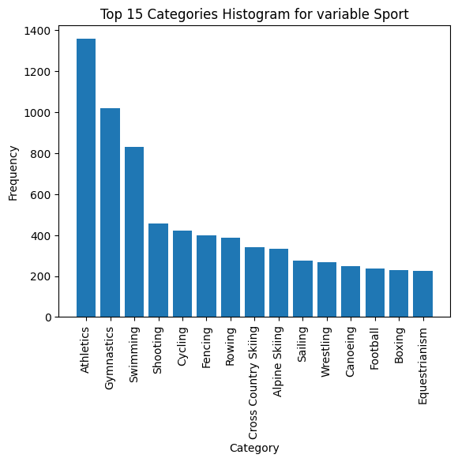

```python
test_class.plot_vars('Sport', N_adj=15)
```

Para estudiar el comportamiento inter-variables es posible construir una matriz de correlación para las variables numéricas, y una matriz de Cramer V para las variables categóricas. No se entregar ningun parámetro para que estas se generen. Ocurrirá de manera automática si se llama a la función plot_vars con una lista de variables. Eso si, tanto para la matriz de correlación como la matriz de Cramer V es necesario que hayan al menos dos variables, (al menos dos numéricas para correlación y al menos dos categóricas para Cramer. De contrario es imposible calcular estas matrices).

Matriz de correlación y Cramer V para un subconjunto de las columnas del dataset:

```
Directory 'EDA_10-11-2023/plots' created (overwritten) successfully.
```

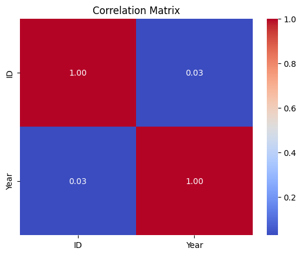

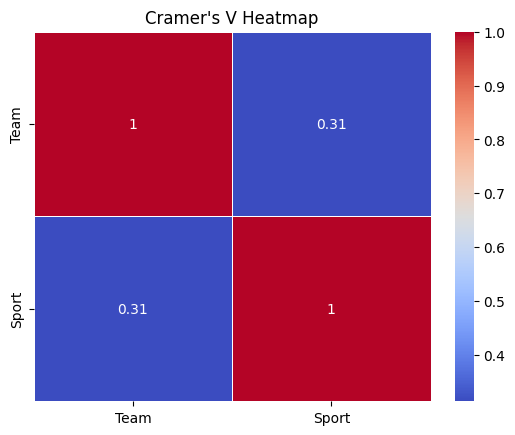

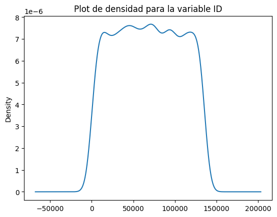

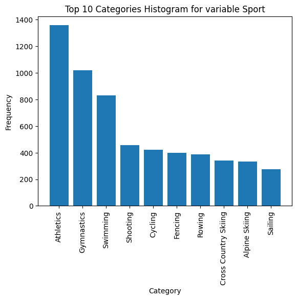

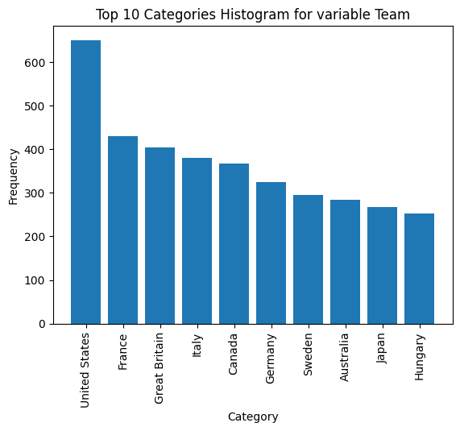

```python
test_class.plot_vars(['Year','ID','Sport','Team'])
```

Todos los gráficos generados se almacenan en formato .pdf dentro del directorio correspondiente.

**¿Como se comportan las variables numéricas? ¿y las categóricas?**

> Para las variables numéricas, se observa una matriz de correlación. No se observan correlaciones numéricas relevantes para el análisis.

**¿Existen relaciones o patrones visuales entre las variables?**

> para las variable numéricas, en esta ocasión no se observan patrones significativos. No se puede decir que existe una correlación importante entre 'ID' y 'Year'. Por el otro lado, para la matriz de Cramer, tampoco hay resultados significantes para las variables 'Sport' y 'Team'.

A pesar de esto, de llamar a la matriz de Cramer para todas las variables categóricas, podría haber un resultado interesante.

## 3. Clusters y anomalías.

Otra funcionalidad implementada en la clase `Profiler()` es la posibilidad de lanzar una clusterización. Sin embargo para esto es necesario limpiar y escalar la data, ya que por ejemplo, no es posible llevar a cabo una clusterización con columnas incompletas, o en columnas no-atómicas.

Anteriormente se observó en el summarize que hay columnas con valores NaNs. Estos deben ser tratados para llevar a cabo la clusterización. Por el otro lado, sabemos que hay columnas no atómicas, vistas en la primera presentación de los datos.

1. Atomiza las variables no atómicas.
2. Elimina elementos duplicados.
3. Elimina valores NaNs.

`clean_data()` informa en la consola el porcentaje de retención de la data y la exporta a un archivo .csv en el directorio asociado a la limpieza.

Si se intenta lanzar `.make_clusters()` sin haber llamado a los métodos `clean_data()` y `.scale()`, se llamarán a estos dentro de `make_clusters()` con su inicialización por defecto.

```python
test_class.clean_data()
```

```
Directory 'EDA_10-11-2023/clean_data' created (overwritten) successfully.
Percentage of data retained: 0.36 %
Data limpia ha sido guardada en:  EDA_10-11-2023/clean_data/data.csv
```

Luego de la limpieza es necesario proceder con un escalamiento para llevar a cabo la clusterización. La función `.scale()` escala las variables del archivo *data.csv* generado por `clean_data()` y aplica codificación a las variables categóricas. El método de codificación es explicitado a través del parámetro `categorical_method` al llamar a la función.

La función `.scale()` exporta los resultados del procesamiento al directorio correspondiente bajo el nombre *scaled_features.csv*.

```python
test_class.scale(categorical_method=LabelEncoder())
#test_class.scale(categorical_method=OneHotEncoder())
```

```
Directory 'EDA_10-11-2023/scaled' created (overwritten) successfully.
Data escalada ha sido exportada a EDA_10-11-2023/scaled/scaled_features.csv
```

Una vez llevado a cabo el procesamiento necesario para hacer una clusterización, se puede llamar al método `.make_clusters()`. Este método recibe el algoritmo de clusterización provisto por el usuario para llevar a cabo una clusterización sobre los datos escalados. La data se importa directamente del archivo creado con el método `.scale()` llamado *scaled_features.csv*.

Por defecto se utiliza label encoder para codificar las variables categóricas.

Es posible seleccionar solo algunas columnas de la data a través de la lista `columns_name`, como ocurre a continuación.

## 4.Resultados

```
Directory 'EDA_10-11-2023/clusters' created (overwritten) successfully.
The file 'EDA_10-11-2023/scaled/scaled_features.csv' exists.
n_clusters is set to None. n_clusters will be initialized via the internal auto_elbow_method function.
```

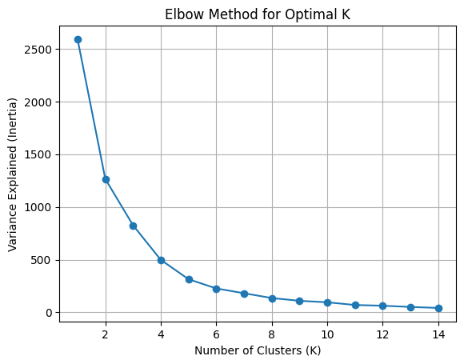

```
Optimal n_clusters is 2
The optimal number of clusters (k) is: 2
```

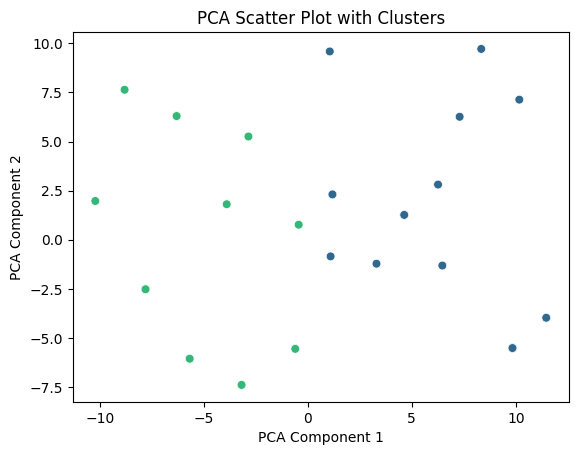

```python
kmeans = KMeans()
#test_class.make_clusters(kmeans)
test_class.make_clusters(kmeans,columns_name=['Games','Season','City','age','weight'])
```

`.make_clusters()` exporta el dataset con el número de cluster asignado al directorio correspondiente bajo el nombre *data_clusters.csv*.

Bajo ciertas condiciones, se logra una separación efectiva de los datos. A continuación se muestran los resultados de utilizar otros métodos de clusterización, y con distintas combinaciones de columnas.

```
Directory 'EDA_10-11-2023/clusters' created (overwritten) successfully.
The file 'EDA_10-11-2023/scaled/scaled_features.csv' exists.
```

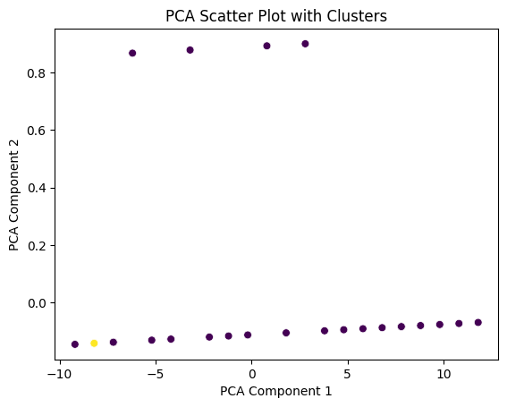

```python
dbscan = DBSCAN()
test_class.make_clusters(dbscan,columns_name=['Games','Season'])
```

No se observan buenos resultados.

Al utilizar agglomerative clustering por defecto y usando todas las columnas se obtiene lo siguiente:

```
Directory 'EDA_10-11-2023/clusters' created (overwritten) successfully.
The file 'EDA_10-11-2023/scaled/scaled_features.csv' exists.
```

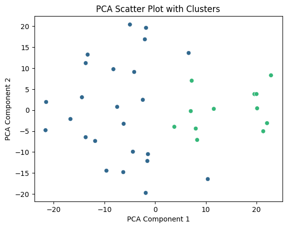

```python
agg= AgglomerativeClustering()
test_class.make_clusters(agg)
```

En donde sí se observan dos clusters.

### Detección de anomalías

La detección de anomalías es importante porque, como dice su nombre, permite detectar anomalías en la data. Al no ser detectadas estas podrían introducir problemas. Por ejemplo, podrían transmitir un bias si se construye un modelo, podrían movilizar erróneamente variables estadísticas como el promedio, la desviación estándar, etc.

El algoritmo IsolationForest() es una buena opción como algoritmo de detección de anomalías. Se comporta adecuadamente ante grandes volúmenes de data e identifica hasta los casos menos comunes de ocurrencia dentro de un dataset (en otras palabras, detecta a los outliers más dificiles de detectar). Se considera un algoritmo robusto ante la mayoría de las distribuciones de datos, siendo agnóstico a estas variaciones.

En el método `.detect_anomalies()` se ha implementado un pipeline de procesamiento de detección de anomalías. La función recibe un algoritmo de detección de anomalías y utiliza la data de *scaled_features.csv* para encontrar outliers. De no haberse creado los archivos correspondientes (*scaled_features.csv*) llama a los métodos necesarios para crear este archivo.

```
Directory 'EDA_10-11-2023/anomalies' created (overwritten) successfully.
The file 'EDA_10-11-2023/scaled/scaled_features.csv' exists.
('pca', PCA(n_components=2))
```

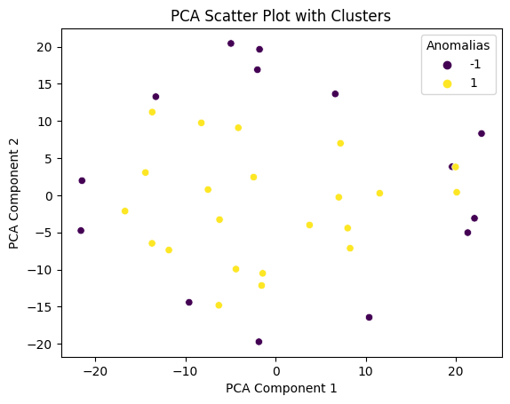

```
Anomalias guardadas en:  EDA_10-11-2023/anomalies/data_anomalies.csv
```

```python
test_class.detect_anomalies(IsolationForest())
```

**¿Existen anomalías notables o preocupantes en los datos?**

> El algoritmo de isolation forest ha arrojado que sí hay anomalías en el dataset.

Finalmente, dado que puede que el perfilador genere mucha data, es posible llamar al método `.clearGarbage()` para borrar toda la data generada en el directorio.

```python
test_class.clearGarbage()
```

Si bien hasta ahora se han llamado los métodos individualmente para demostrar las distintas funcionalidades de la clase, también es posible hacer un llamado al método `.profile()`. El cual llamará a todos los métodos descritos hasta ahora. Estos métodos utilizaran los argumentos por defecto para llevar a cabo el procesamiento.

Si no se presentan columnas atómicas, entonces basta con ingresar None en el input.

```
Summary.txt has been successfully exported too EDA_10-11-2023

------------------------------------------------------------
Los tipos de las variables son:
ID: int64
Name: object
Sex: object
Team: object
NOC: object
Games: object
Year: int64
Season: object
City: object
Sport: object
Event: object
Medal: object
age-height-weight: object
------------------------------------------------------------
Cantidad de NaNs por variable:
ID: 0
Name: 0
Sex: 0
Team: 0
NOC: 0
Games: 0
Year: 0
Season: 0
City: 0
Sport: 0
Event: 0
Medal: 8577
age-height-weight: 0
------------------------------------------------------------
Cantidad de valores Ãºnicos por variable:
ID: 9511
Name: 9501
Sex: 2
Team: 391
NOC: 207
Games: 51
```

[output cut: 37 more lines]

```
------------------------------------------------------------
Percentil 50.0 de las variables numericas:
ID: 67950.0
Year: 1988.0
------------------------------------------------------------
Percentil 75.0 de las variables numericas:
ID: 101312.25
Year: 2002.0
------------------------------------------------------------
Percentil 100.0 de las variables numericas:
ID: 135566.0
Year: 2016.0
------------------------------------------------------------

Directory 'EDA_10-11-2023/plots' created (overwritten) successfully.
```

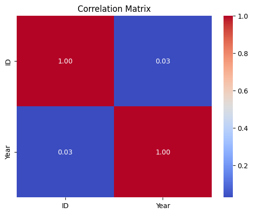

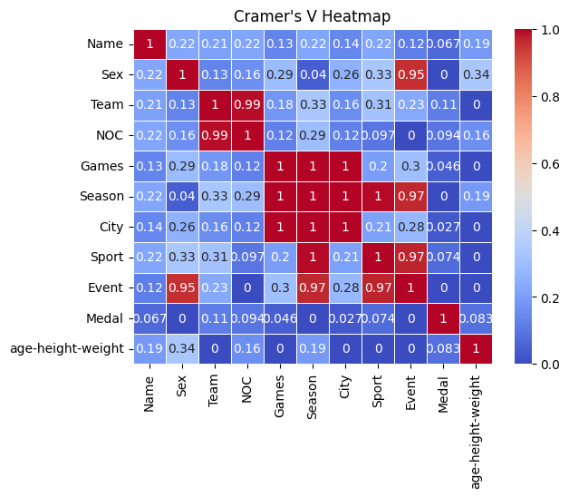

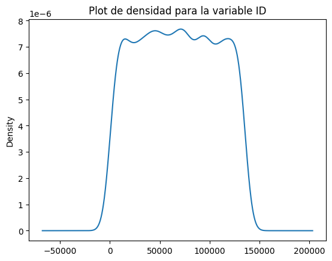

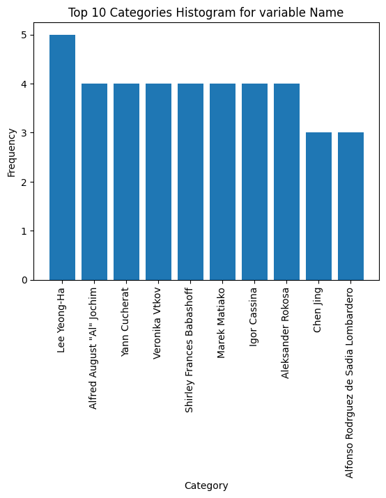

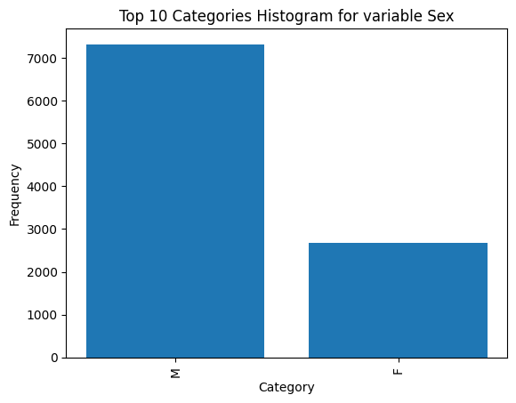

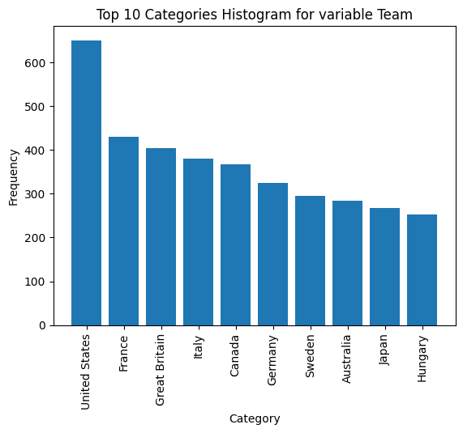

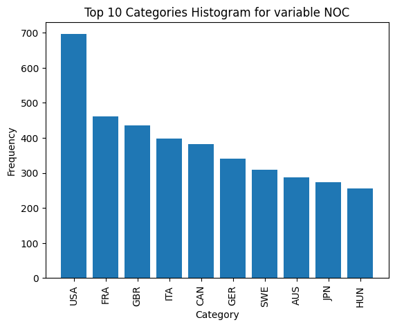

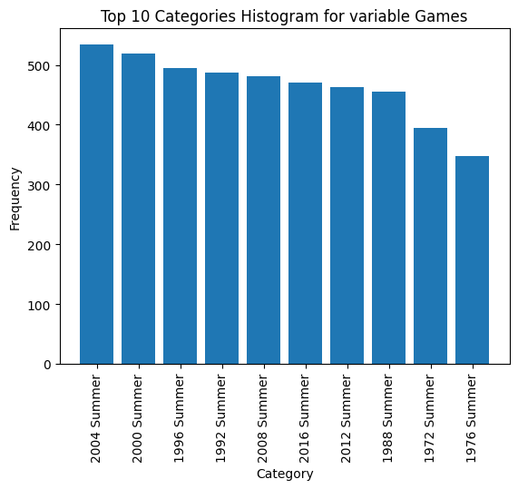

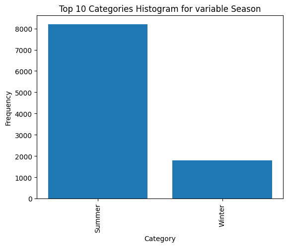

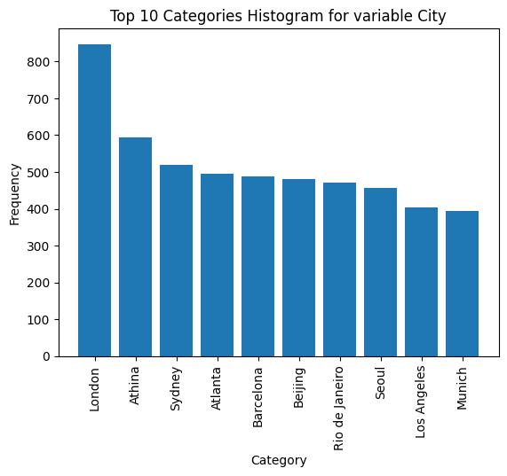

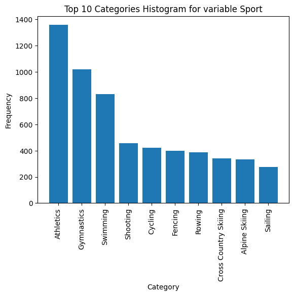

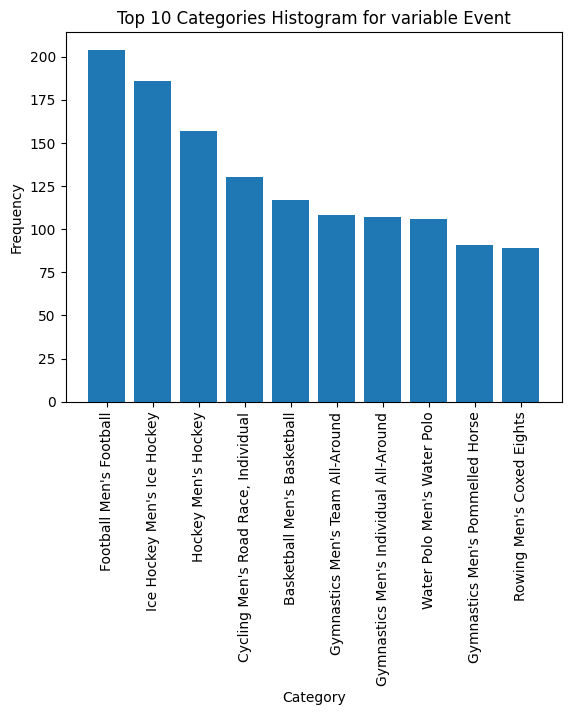

[5 more figures not shown]

```
Anomalias guardadas en:  EDA_10-11-2023/anomalies/data_anomalies.csv
```

```python
test_class.profile()
```

## 5. Conclusión

En las variables numéricas no se encuentran valores negativos. En este contexto es esperable puesto a que las variables numéricas corresponden a 'ID' y 'Year'. Por definición, ninguna de estas debe tener valores negativos.

Por el otro lado, gracias a las matrices de correlación y Cramer V es posible visualizar si existen correlaciones entre las variables, y con los gráficos de densidad es posible observar como se distribuyen las variables numéricas. Con los histogramas, se puede estudiar la distribución de las variables categóricas.

Con clean_data y scale se puede preparar la data para llevar a cabo un estudio de clusters y también un estudio de detección de anomalías, lo cual es escencial al trabajar con un gran volumen de datos. Sin embargo, la efectividad de estos métodos de clusterización dependerán de las columnas seleccionadas, y la separabilidad inherente de los elementos del dataset. Podría darse que los clusters generados para un dataset arbitrario no separen efectivamente la data.

La exportación de la data es extremadamente útil, ya que significa que los datos pueden ser enviados a otros usuarios o computadoras, y la herramienta clearGarbage permite deshacerse rápidamente de la información generada.

En este proyecto se ha visto la efectividad de construir una clase perfiladora agnóstica al dataset, puesto que ahora será posible ejecutar múltiples EDAs sobre cualquier dataset de manera rápida y eficaz.